# Projekt

Szymon Popkiewicz, Kacper Prorok

2024-03-22

```r
library(tidyverse)
library(ggplot2)
library(metRology)
```

# Część 1

*W części pierwszej nasze X są losowane z rozkładu jednostajnego [0,20] a E z rozkładu N(0,sigma).*

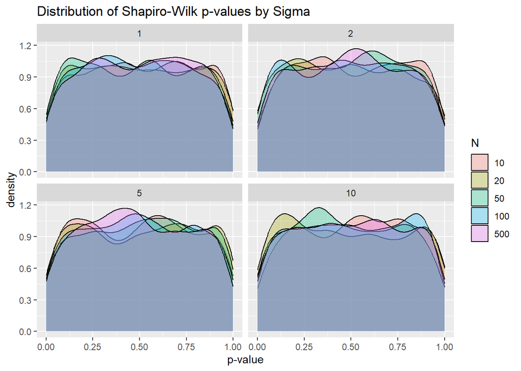

```r
df <- data.frame("n" = 0, "sigma" = 0,"p_val_shap"=0,"p_val_ks"=0)
#rownames(df)<-NULL
sigmas<-c(1,2,5,10)
ns<-c(10,20,50,100,500)
b<-2
a<-1


#CZESC 1
for(n in ns)
{
  for(sig in sigmas)
  {
    for(i in 1:1000)
    {
      x<-runif(n,0,20)
      epsilon<-rnorm(n,0,sig)
      y<-x*b + a + epsilon
      model<-lm(y~x)
      cof<-data.frame(x=x,y=y)
      #cof$y_model=cof$x*model$coefficients[2] + model$coefficients[1]
      #cof$reszty=cof$y-cof$y_model
      cof$reszty= cof$y - (cof$x*model$coefficients[2] + model$coefficients[1])
      shap = shapiro.test(cof$reszty)$p.value
      ks = ks.test(cof$reszty, "pnorm",mean=mean(cof$reszty),sd=sd(cof$reszty))$p.value
      df<-rbind(df,c(n,sig,shap,ks))
    }
  }
}
df<-df[-1,]
rownames(df)<-NULL
#df%>%
##  ggplot(aes(x=factor(n),y=p_val_shap))+
 # geom_boxplot()+
#  facet_wrap(~sigma)

# df%>%
#   ggplot(aes(x=p_val_shap,fill=factor(sigma)))+
#   geom_density(alpha=0.3)+
#   facet_wrap(~n)+
#   labs(title = "Distribution of Shapiro-Wilk p-values by N",
#        fill="Sigma",
#        x="p-value",
#        y="Density")

df%>%
  ggplot(aes(x=p_val_shap,fill=factor(n)))+
  geom_density(alpha=0.3)+
  facet_wrap(~sigma)+
  labs(title = "Distribution of Shapiro-Wilk p-values by Sigma",
       fill="N")+
  xlab("p-value")+
  ylab("density")
```

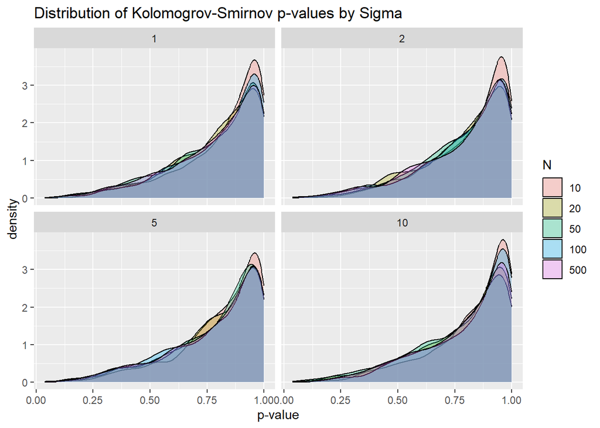

```r
# df%>%
#   ggplot(aes(x=p_val_ks,fill=factor(sigma)))+
#   geom_density(alpha=0.3)+
#   facet_wrap(~n)+
#   labs(title = "Distribution of Kolomogrov-Smirnov p-values by N",
#        fill="Sigma",
#        x="p-value",
#        y="Density")

df%>%
  ggplot(aes(x=p_val_ks,fill=factor(n)))+
  geom_density(alpha=0.3)+
  facet_wrap(~sigma)+
  labs(title = "Distribution of Kolomogrov-Smirnov p-values by Sigma",
       fill="N")+
  xlab("p-value")+
  ylab("density")
```

Do badania czy reszty naszego modelu mają rozkład normalny użyliśmy dwóch testów - test Shapiro-Wilka oraz test Kolomogrova-Smirnova.

Wnioski:

W przypadku testu Shapiro-Wilka jest zdecydowana większość przyjęć hipotezy H0(reszty mają rozkład normalny), choć zdarzały się przypadki odrzucenia tej hipotezy. Test Kolomogorova-Smirnova praktycznie w każdym przypadku przyjął hipotezę H0(reszty mają rozkład normalny). W przypadku obydwóch testów liczba danych(czyli liczba reszt modelu) oraz parametr sigma nie mają większego wpływu na rozkłady p-value.

## Tabelki z odsetkami odrzuceń hipotezy H0

Shapiro-wilk

```r
df%>%
  group_by(n,sigma)%>%
  summarize(m=mean(p_val_shap<0.05))%>%
  pivot_wider(names_from = sigma, values_from = m)
```

```
## # A tibble: 5 × 5
## # Groups:   n [5]
##       n   `1`   `2`   `5`  `10`
##   <dbl> <dbl> <dbl> <dbl> <dbl>
## 1    10 0.044 0.04  0.052 0.038
## 2    20 0.049 0.069 0.047 0.054
## 3    50 0.05  0.037 0.046 0.054
## 4   100 0.042 0.05  0.048 0.047
## 5   500 0.05  0.043 0.053 0.052
```

W przypadku testu Shapiro-wilka pojawiły się rozkłady, które został uznane za niezgodne z rozkładem normalnym, ale odsetki te są bardzo małe i raczej nie są zależne od liczby danych oraz od sigmy.

Test Kolomogorova-Smirnova

```r
df%>%
  group_by(n,sigma)%>%
  summarize(m=mean(p_val_ks<0.05))%>%
  pivot_wider(names_from = sigma, values_from = m)
```

```
## # A tibble: 5 × 5
## # Groups:   n [5]
##       n   `1`   `2`   `5`  `10`
##   <dbl> <dbl> <dbl> <dbl> <dbl>
## 1    10     0     0 0     0
## 2    20     0     0 0     0
## 3    50     0     0 0.001 0.001
## 4   100     0     0 0     0
## 5   500     0     0 0.001 0
```

## Wykresy podsumowujące

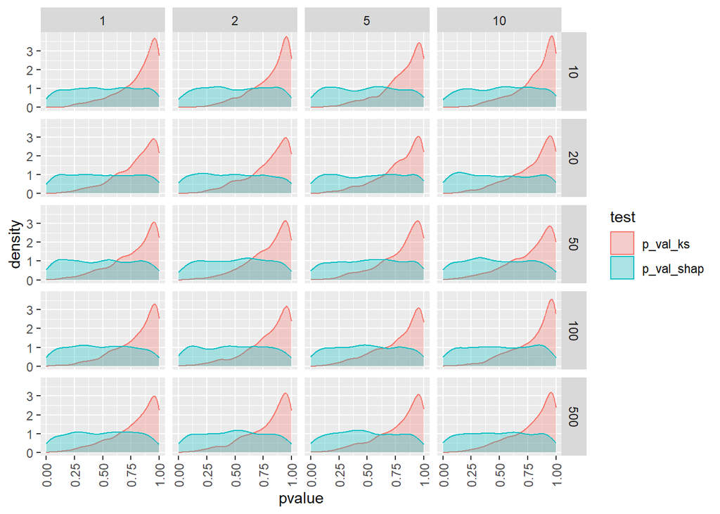

```r
new_df<-df%>%
  pivot_longer(cols=c("p_val_shap","p_val_ks"),names_to = "test",values_to = "pvalue")
  #zamieniam testy na kolumny

new_df%>%
  ggplot(aes(x=pvalue,color=test,fill=test))+
  geom_density(alpha=0.3)+
  facet_grid(n~sigma)+
  theme(axis.text.x = element_text(angle = 90, hjust = 1, vjust = 0.5))
```

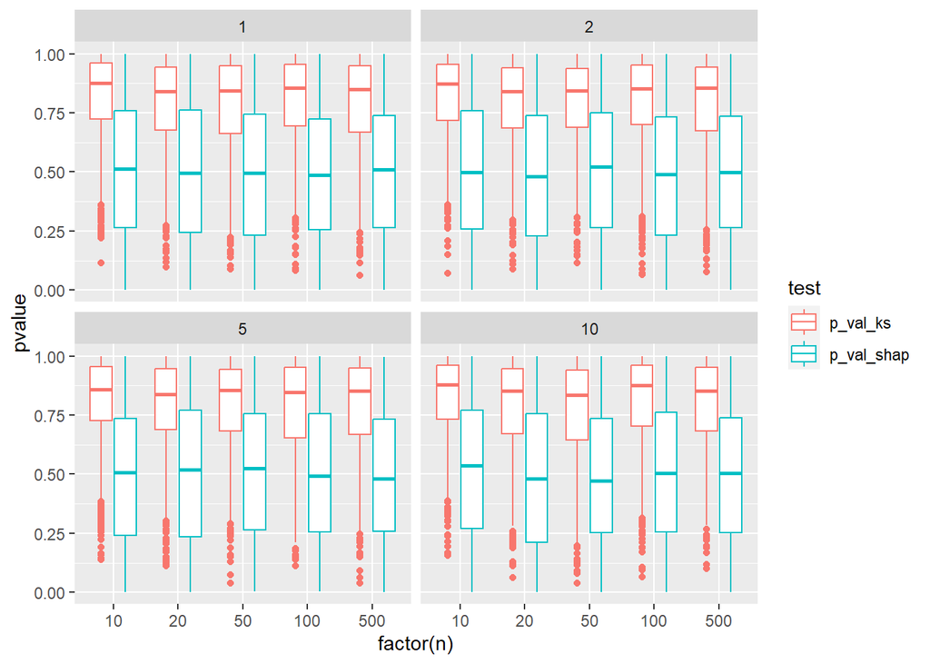

```r
new_df%>%
ggplot(aes(x=factor(n),y=pvalue,color=test))+
  geom_boxplot()+
  facet_wrap(~sigma)
```

Na powyższych wykresach został zebrane naraz rozkłady p-value z dwóch testów naraz. Główne wnioski rzucające się w oczy to różnica w rozkładach między dwoma testami, ale w obydwóch przypadkach sigma oraz liczba N mają praktycznie zerowy wpływ na rozkład p-value.

# Część 2

*W części drugiej nasze X są losowane z rozkładu jednostajnego [0,200] a E z rozkładu N(0,sigma).*

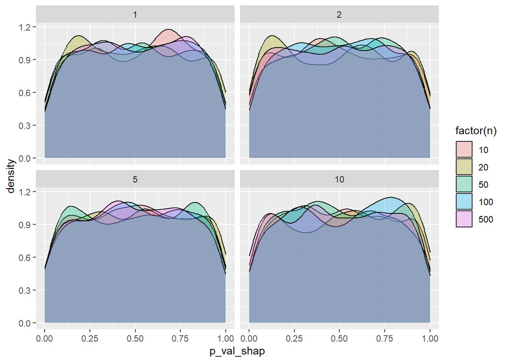

```r
#CZESC 2

df2 <- data.frame("n" = 0, "sigma" = 0,"p_val_shap"=0,"p_val_ks"=0)
for(n in ns)
{
  for(sig in sigmas)
  {
    for(i in 1:1000)
    {
      x<-runif(n,0,200)
      epsilon<-rnorm(n,0,sig)
      y<-x*b + a + epsilon
      model<-lm(y~x)
      cof<-data.frame(x=x,y=y)
      #cof$y_model=cof$x*model$coefficients[2] + model$coefficients[1]
      #cof$reszty=cof$y-cof$y_model
      cof$reszty= cof$y - (cof$x*model$coefficients[2] + model$coefficients[1])
      shap = shapiro.test(cof$reszty)$p.value
      ks = ks.test(cof$reszty, "pnorm",mean=mean(cof$reszty),sd=sd(cof$reszty))$p.value
      df2<-rbind(df2,c(n,sig,shap,ks))
    }
  }
}


df2<-df2[-1,]
rownames(df)<-NULL


df2%>%
  ggplot(aes(x=p_val_shap,fill=factor(n)))+
  geom_density(alpha=0.3)+
  facet_wrap(~sigma,ncol=2)
```

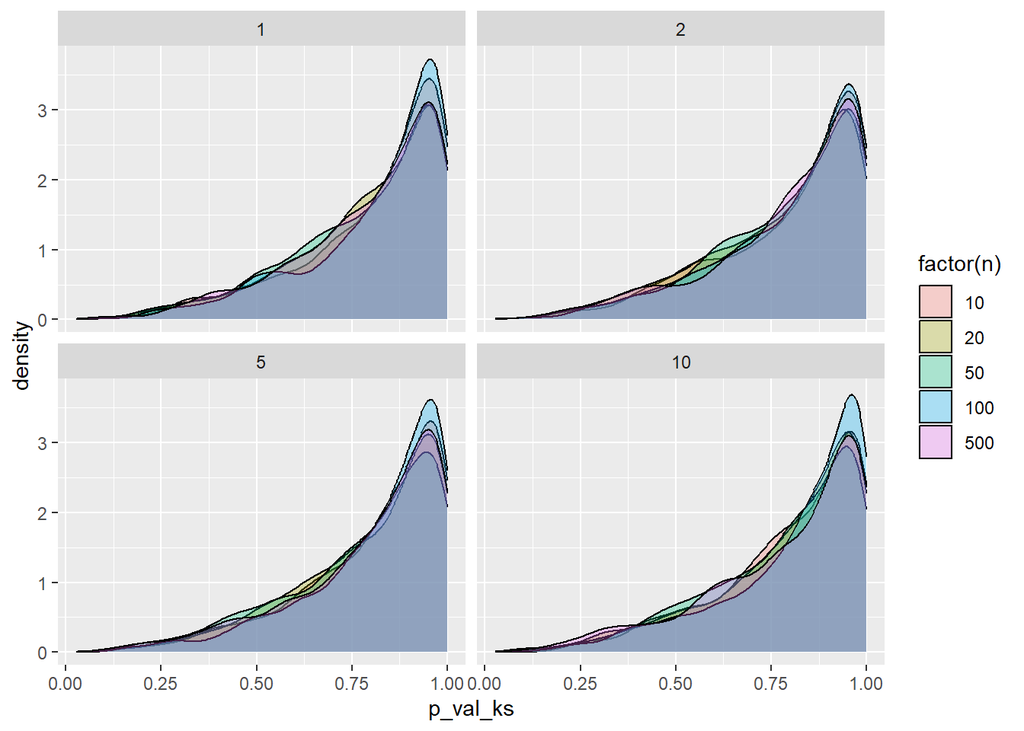

```r
df2%>%
  ggplot(aes(x=p_val_ks,fill=factor(n)))+
  geom_density(alpha=0.3)+
  facet_wrap(~sigma, ncol=2)
```

W przypadku, gdy nasze X są losowane z rozkładu jednostajnego [0,200] w zasadzie możemy wyciągnąć te same wnioski, co w przypadku rozkładu [0,20]. Ponownie test Shapiro-Wilka w bardzo niewielu przypadkach odrzucił hipotezę H0, a test Kolomogorova-Smirnova w zasadzie w każdym przypadku przyjął H0. Rozkłady te również raczej nie zależą od sigmy oraz liczby N.

## Tabelki z odsetkami odrzuceń hipotezy H0

Shapiro-Wilk:

```r
df2%>%
  group_by(n,sigma)%>%
  summarize(m=mean(p_val_shap<0.05))%>%
  pivot_wider(names_from = sigma, values_from = m)
```

```
## # A tibble: 5 × 5
## # Groups:   n [5]
##       n   `1`   `2`   `5`  `10`
##   <dbl> <dbl> <dbl> <dbl> <dbl>
## 1    10 0.055 0.067 0.045 0.048
## 2    20 0.044 0.062 0.047 0.048
## 3    50 0.057 0.053 0.046 0.041
## 4   100 0.045 0.046 0.055 0.047
## 5   500 0.043 0.056 0.052 0.075
```

Nie widać większych różnic od wariantu z losowaniem X z rozkładu [0,20]. Ponownie nie widać zależności między odsetkiem odrzuceń, a wartością sigmy oraz liczby N.

```r
df2%>%
  group_by(n,sigma)%>%
  summarize(m=mean(p_val_ks<0.05))%>%
  pivot_wider(names_from = sigma, values_from = m)
```

```
## # A tibble: 5 × 5
## # Groups:   n [5]
##       n   `1`   `2`   `5`  `10`
##   <dbl> <dbl> <dbl> <dbl> <dbl>
## 1    10     0 0.001     0     0
## 2    20     0 0         0     0
## 3    50     0 0         0     0
## 4   100     0 0         0     0
## 5   500     0 0.001     0     0
```

Również bardzo podobne wyniki i wnioski takie jak w przypadku rozkładu [0,20].

## Wykresy podsumowujące

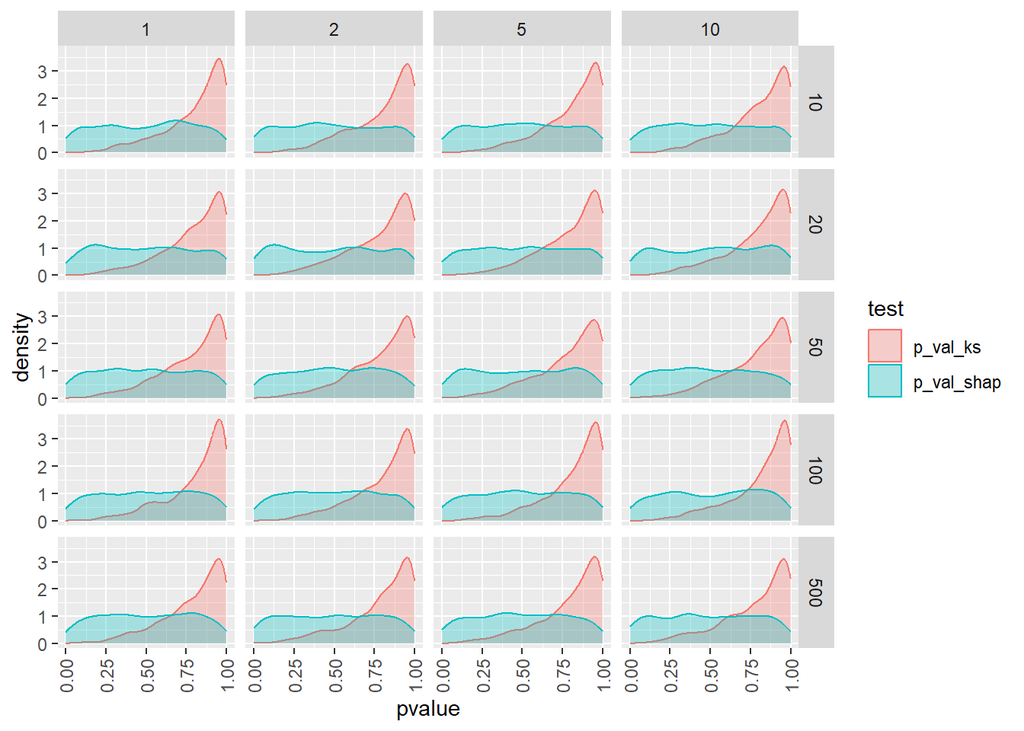

```r
new_df2<-df2%>%
  pivot_longer(cols=c("p_val_shap","p_val_ks"),names_to = "test",values_to = "pvalue")
#zamieniam testy na kolumny

new_df2%>%
  ggplot(aes(x=pvalue,color=test,fill=test))+
  geom_density(alpha=0.3)+
  facet_grid(n~sigma)+
  theme(axis.text.x = element_text(angle = 90, hjust = 1, vjust = 0.5))
```

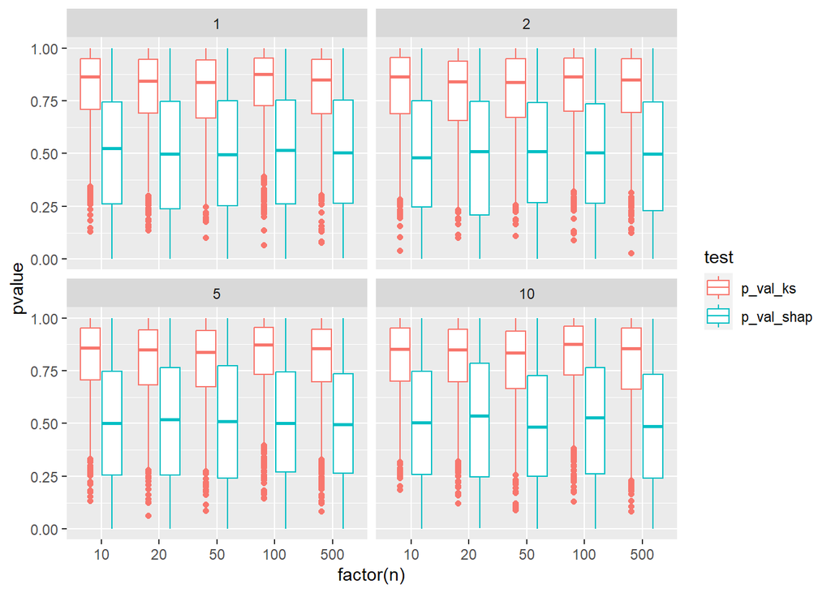

```r
new_df2%>%
  ggplot(aes(x=factor(n),y=pvalue,color=test))+
  geom_boxplot()+
  facet_wrap(~sigma)
```

# Część 3

*W części trzeciej nasze X są losowane z rozkładu jednostajnego [0,20] a E z rozkładu T-studenta o 3 stopniach swobody, który został przeskalowany tak by uwzględniał naszą sigmę.*

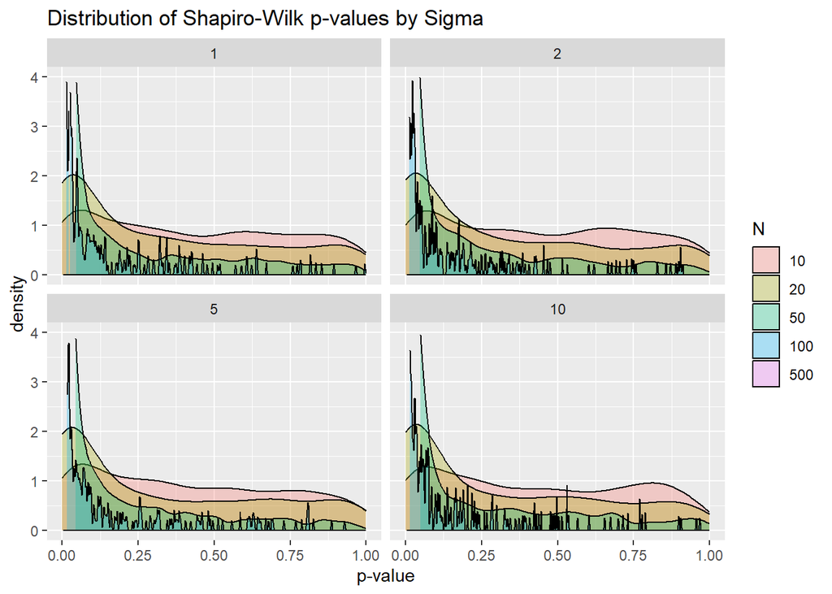

```r
### czesc 3
df3 <- data.frame("n" = 0, "sigma" = 0,"p_val_shap"=0,"p_val_ks"=0)

for(n in ns)
{
  for(sig in sigmas)
  {
    for(i in 1:1000)
    {
      x<-runif(n,0,20)
      epsilon<-rt.scaled(n,3,mean = 0,sd=sig)
      y<-x*b + a + epsilon
      model<-lm(y~x)
      cof<-data.frame(x=x,y=y)
      #cof$y_model=cof$x*model$coefficients[2] + model$coefficients[1]
      #cof$reszty=cof$y-cof$y_model
      cof$reszty= cof$y - (cof$x*model$coefficients[2] + model$coefficients[1])
      shap = shapiro.test(cof$reszty)$p.value
      ks = ks.test(cof$reszty, "pnorm",mean=mean(cof$reszty),sd=sd(cof$reszty))$p.value
      df3<-rbind(df3,c(n,sig,shap,ks))
    }
  }
}



df3<-df3[-1,]
rownames(df3)<-NULL


df3%>%
  ggplot(aes(x=p_val_shap,fill=factor(n)))+
  geom_density(alpha=0.3)+
  facet_wrap(~sigma,ncol=2)+
  labs(title = "Distribution of Shapiro-Wilk p-values by Sigma",
       fill="N")+
  ylim(0,4)+
  xlab("p-value")+
  ylab("density")
```

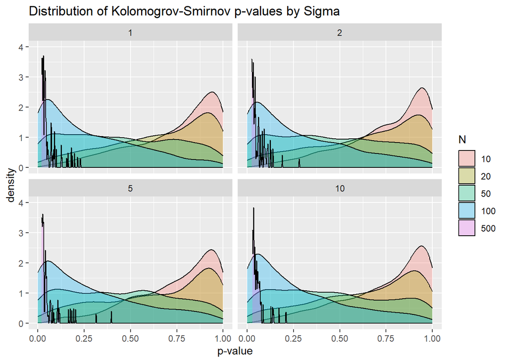

```r
df3%>%
  ggplot(aes(x=p_val_ks,fill=factor(n)))+
  geom_density(alpha=0.3)+
  facet_wrap(~sigma,ncol=2)+
  labs(title = "Distribution of Kolomogrov-Smirnov p-values by Sigma",
       fill="N")+
  ylim(0,4)+
  xlab("p-value")+
  ylab("density")
```

W przypadku gdy E jest losowane z rozkładu t-studenta, *pojawiają się pewne zależności.* W przypadku obu testów widzimy, że hipoteza H0(reszty mają rozkład normalny) jest dużo częśćiej odrzucana, niż we wcześniejszych częściach. Dla Shapiro-Wilka widzimy załamanie dla n=100, a dla n=500, praktycznie zero przyjęć H0. Dla Kolmogorova-Smirnova, przy małym n, mamy podobną sytuację jak dla E z rozkładu normalnego, jednak ze wzrostem ‘n’, szala przechyla się na korzyść odrzucenia H0. Raczej zależność między gęstością, a sigmą jest niewielka.

## Tabelki z odsetkami odrzuceń hipotezy H0

Shapiro-Wilk:

```r
df3%>%
  group_by(n,sigma)%>%
  summarize(m=mean(p_val_shap<0.05))%>%
  pivot_wider(names_from = sigma, values_from = m)
```

```
## # A tibble: 5 × 5
## # Groups:   n [5]
##       n   `1`   `2`   `5`  `10`
##   <dbl> <dbl> <dbl> <dbl> <dbl>
## 1    10 0.147 0.129 0.14  0.133
## 2    20 0.288 0.303 0.322 0.301
## 3    50 0.619 0.61  0.626 0.612
## 4   100 0.859 0.862 0.854 0.868
## 5   500 1     1     1     1
```

Kolomogrov-Smirnov:

```r
df3%>%
  group_by(n,sigma)%>%
  summarize(m=mean(p_val_ks<0.05))%>%
  pivot_wider(names_from = sigma, values_from = m)
```

```
## # A tibble: 5 × 5
## # Groups:   n [5]
##       n   `1`   `2`   `5`  `10`
##   <dbl> <dbl> <dbl> <dbl> <dbl>
## 1    10 0.001 0     0     0.001
## 2    20 0.018 0.027 0.024 0.025
## 3    50 0.1   0.092 0.092 0.075
## 4   100 0.224 0.22  0.218 0.223
## 5   500 0.972 0.962 0.978 0.974
```

Potwierdza się to, co było widoczne na wykresach. *Wraz ze wzrostem liczby N rośnie odsetek odrzuceń hipotezy H0.* Dla największego ‘n’ niemalże 100% testów jest odrzucanych.

## Wykresy podsumowujące

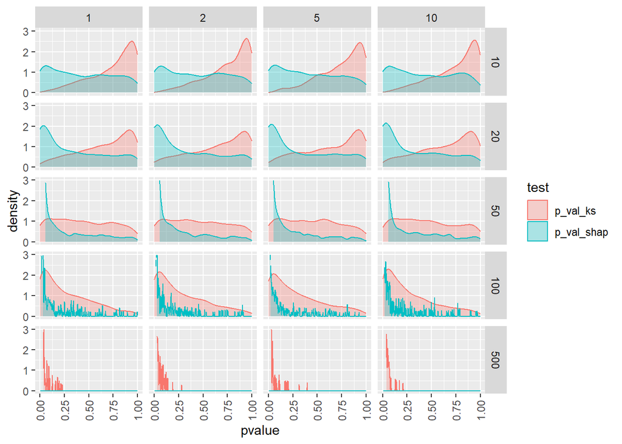

```r
new_df3<-df3%>%
  pivot_longer(cols=c("p_val_shap","p_val_ks"),names_to = "test",values_to = "pvalue")
#zamieniam testy na kolumny

new_df3%>%
  ggplot(aes(x=pvalue,color=test,fill=test))+
  geom_density(alpha=0.3)+
  ylim(0,3)+
  facet_grid(n~sigma)+
  theme(axis.text.x = element_text(angle = 90, hjust = 1, vjust = 0.5))
```

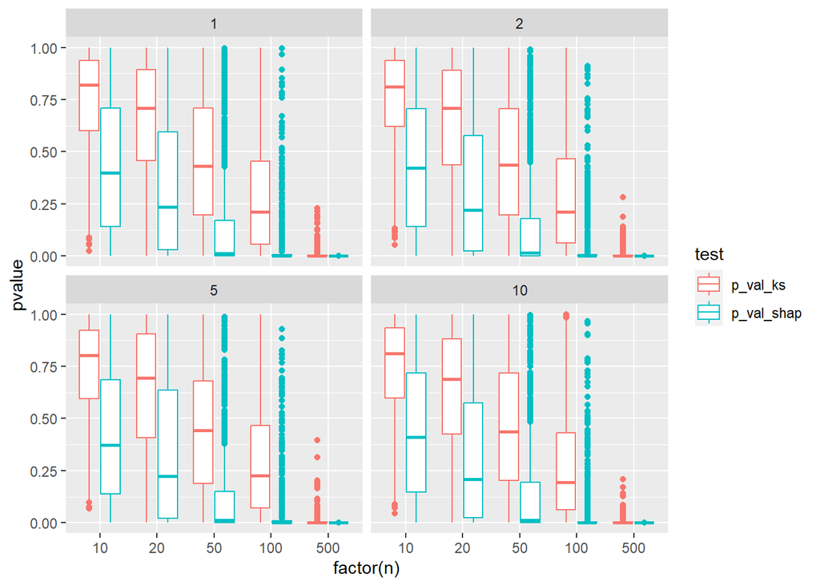

```r
new_df3%>%
  ggplot(aes(x=factor(n),y=pvalue,color=test))+
  geom_boxplot()+
  facet_wrap(~sigma,ncol=2)
```

# Cześć 4

*W części trzeciej nasze X są losowane z rozkładu jednostajnego [0,200] a E z rozkładu T-studenta o 3 stopniach swobody, który został przeskalowany tak by uwzględniał naszą sigmę.*

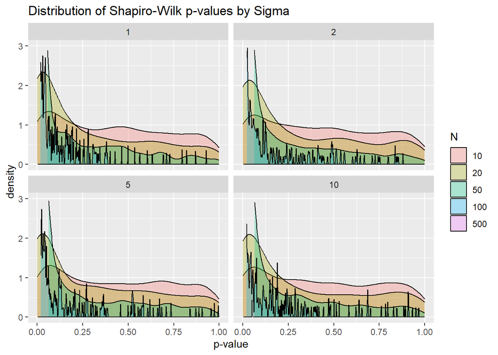

```r
### czesc 3
df4 <- data.frame("n" = 0, "sigma" = 0,"p_val_shap"=0,"p_val_ks"=0)
for(n in ns)
{
  for(sig in sigmas)
  {
    for(i in 1:1000)
    {
      x<-runif(n,0,200)
      epsilon<-rt.scaled(n,3,mean = 0,sd=sig)
      y<-x*b + a + epsilon
      model<-lm(y~x)
      cof<-data.frame(x=x,y=y)
      #cof$y_model=cof$x*model$coefficients[2] + model$coefficients[1]
      #cof$reszty=cof$y-cof$y_model
      cof$reszty= cof$y - (cof$x*model$coefficients[2] + model$coefficients[1])
      shap = shapiro.test(cof$reszty)$p.value
      ks = ks.test(cof$reszty, "pnorm",mean=mean(cof$reszty),sd=sd(cof$reszty))$p.value
      df4<-rbind(df4,c(n,sig,shap,ks))
    }
  }
}



df4<-df4[-1,]
rownames(df4)<-NULL




df4%>%
  ggplot(aes(x=p_val_shap,fill=factor(n)))+
  geom_density(alpha=0.3)+
  facet_wrap(~sigma,ncol=2)+
  labs(title = "Distribution of Shapiro-Wilk p-values by Sigma",
       fill="N")+
  ylim(0,3)+
  xlab("p-value")+
  ylab("density")
```

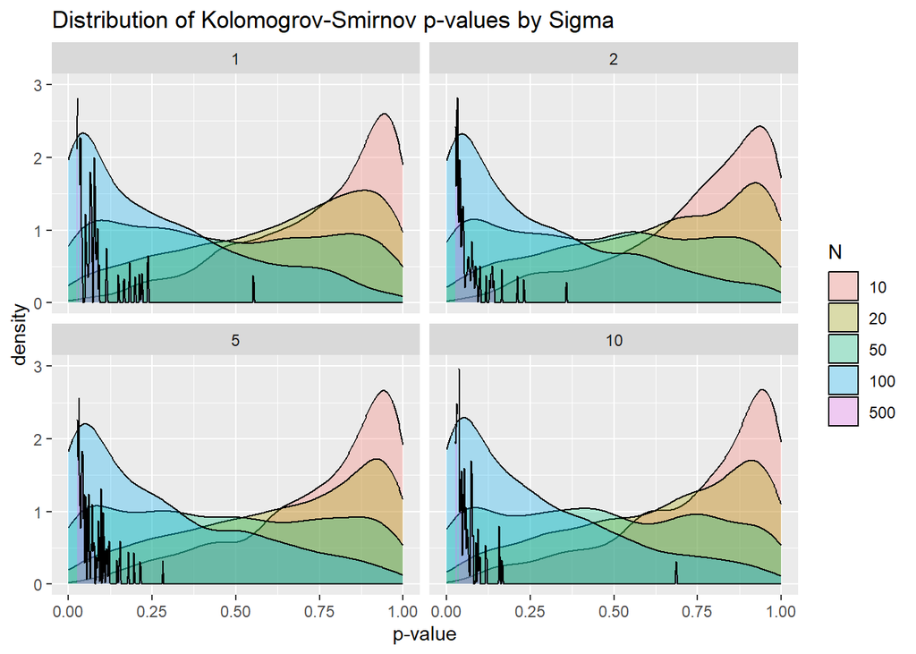

```r
df4%>%
  ggplot(aes(x=p_val_ks,fill=factor(n)))+
  geom_density(alpha=0.3)+
  facet_wrap(~sigma,ncol=2)+
  labs(title = "Distribution of Kolomogrov-Smirnov p-values by Sigma",
       fill="N")+
  ylim(0,3)+
  xlab("p-value")+
  ylab("density")
```

## Tabelki z odsetkami odrzuceń hipotezy H0

Shapiro-Wilk:

```r
df4%>%
  group_by(n,sigma)%>%
  summarize(m=mean(p_val_shap<0.05))%>%
  pivot_wider(names_from = sigma, values_from = m)
```

```
## # A tibble: 5 × 5
## # Groups:   n [5]
##       n   `1`   `2`   `5`  `10`
##   <dbl> <dbl> <dbl> <dbl> <dbl>
## 1    10 0.143 0.141 0.134 0.143
## 2    20 0.335 0.299 0.31  0.3
## 3    50 0.633 0.591 0.59  0.573
## 4   100 0.878 0.86  0.869 0.863
## 5   500 1     1     1     0.999
```

Kolomogrov-Smirnov:

```r
df4%>%
  group_by(n,sigma)%>%
  summarize(m=mean(p_val_ks<0.05))%>%
  pivot_wider(names_from = sigma, values_from = m)
```

```
## # A tibble: 5 × 5
## # Groups:   n [5]
##       n   `1`   `2`   `5`  `10`
##   <dbl> <dbl> <dbl> <dbl> <dbl>
## 1    10 0.001 0     0.002 0.002
## 2    20 0.027 0.022 0.019 0.015
## 3    50 0.089 0.103 0.097 0.095
## 4   100 0.251 0.254 0.233 0.222
## 5   500 0.959 0.97  0.964 0.969
```

## Wykresy podsumowujące

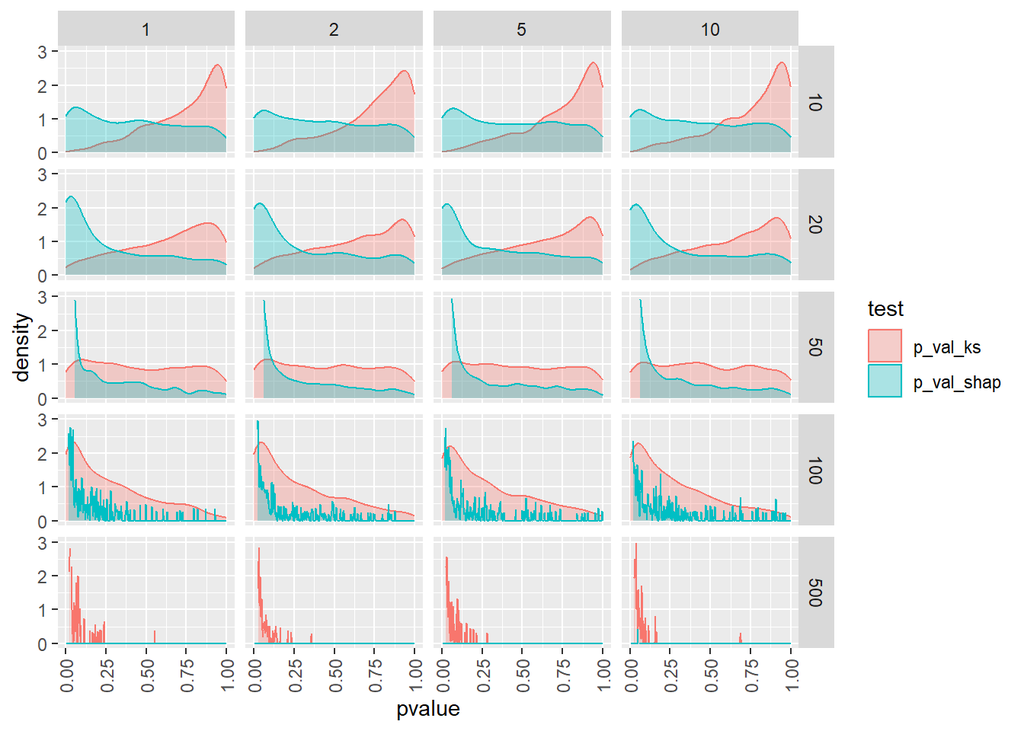

```r
new_df4<-df4%>%
  pivot_longer(cols=c("p_val_shap","p_val_ks"),names_to = "test",values_to = "pvalue")
#zamieniam testy na kolumny

new_df4%>%
  ggplot(aes(x=pvalue,color=test,fill=test))+
  geom_density(alpha=0.3)+
  ylim(0,3)+
  facet_grid(n~sigma)+
  theme(axis.text.x = element_text(angle = 90, hjust = 1, vjust = 0.5))
```

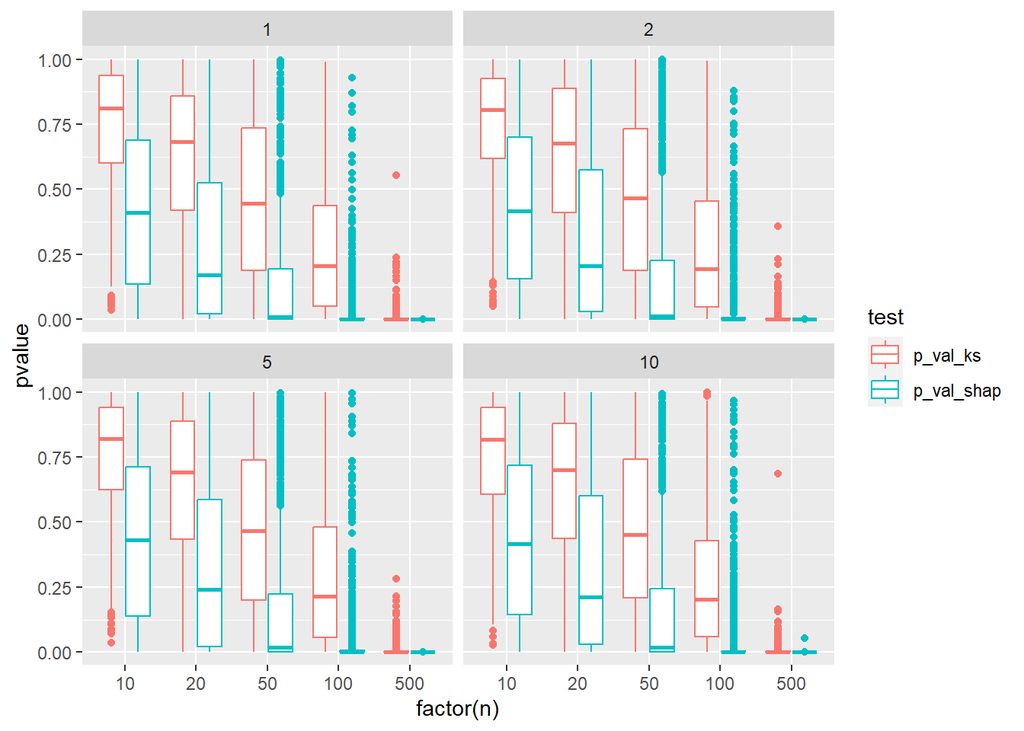

```r
new_df4%>%
ggplot(aes(x=factor(n),y=pvalue,color=test))+
  geom_boxplot()+
  facet_wrap(~sigma)
```

*Wyniki adekwatne do tych w części trzeciej.*